# BCR + GEX Integration Tutorial – Part 1: BCR Sequence Processing

From Immcantation output to a clean, clone-annotated BCR table

Nachi Nathan

2026-05-21

# Prerequisites

Before running this part of the tutorial, make sure the following are in place.

**VDJ assignment completed** This tutorial picks up after V(D)J gene assignment has been run on your Cell Ranger output using the Immcantation Docker container. If you have not done this yet, work through `00_Docker_Setup_and_VDJ_Assignment.md` first. That guide covers installing Docker, pulling the Immcantation image, and running `AssignGenes.py` and `MakeDb.py` to produce the AIRR TSV files used here.

**Input files required**

| File | Where it comes from |
| --- | --- |
| `<sample>_airr_db-pass.tsv` | Output of `MakeDb.py` from the Docker step |
| `<sample>_filtered_contig_annotations.csv` | Cell Ranger VDJ output, at `per_sample_outs/<sample>/vdj_b/` |
| IMGT germline reference (`human/vdj/`) | Downloaded via fetch_imgtdb.sh from the Immcantation repository (see instructions below) |

All input files for this tutorial are available on Zenodo: https://zenodo.org/records/20323951

**Downloading the IMGT germline reference** Run the following commands in a terminal (not an R session) once before running the tutorial. This clones the Immcantation repository and downloads the formatted IMGT germline sequences to a folder of your choice.

```bash
git clone https://github.com/immcantation/immcantation
immcantation/scripts/fetch_imgtdb.sh -o germlines
```

The human VDJ reference will be at `germlines/human/vdj/`. Set `IMGT_REF_DIR` in the paths chunk to point to this folder.

**R packages required**

```r
install.packages(c("dplyr", "ggplot2", "readr", "stringr"))

# Bioconductor / CRAN immunology packages
install.packages("BiocManager")
BiocManager::install(c("airr", "alakazam", "dowser", "scoper", "shazam"))
```

**R version:** This tutorial was developed under R 4.3. Any R 4.x version should work.

# Overview

This part of the tutorial covers BCR sequence processing using the Immcantation R toolkit. Starting from the AIRR TSV produced by IgBLAST, we QC and filter the sequences, assign B cell clones, reconstruct germline sequences, and calculate somatic hypermutation (SHM). The output is a clean, annotated TSV per sample that feeds into Part 2 (Seurat integration) and Part 3 (repertoire visualization).

The dataset comes from Nathan et al., *Immunity* (2026), a study of tumor-draining lymph nodes in ovarian cancer patients. We use two samples from the same patient: a lymph node (LN) and a primary tumor (PT). This pairing lets us demonstrate multi-sample handling and cross-tissue clone tracking.

The steps in this part are:

1. **Load and filter** – load the AIRR TSV and Cell Ranger annotations, append sample IDs to barcodes, and apply four sequential QC filters.
2. **Clonal threshold** – determine the CDR3 distance threshold separating clonally related from unrelated sequences.
3. **Clone assignment** – hierarchical clustering to define clones, followed by human-readable clone ID encoding.
4. **Germline reconstruction and SHM** – reconstruct unmutated germlines and calculate per-sequence mutation frequency.
5. **Save** – write a clean TSV per sample for downstream use.
6. **Repertoire overview** – rank-abundance, clone size, and SHM plots to characterize each sample before moving to GEX.

# Setup

## Paths

Set these variables to match your file structure before running anything else. Every path downstream is derived from these, so this is the only place you need to make changes.

```r
# File containing BCR helper functions (BCR_functions.R from the tutorial repo)
BCR_FUNCTIONS_FILE <- "C:/Users/natha/OneDrive/Documents/Immcantation/BCR_Tutorial/Github/BCR_functions.R"

# IMGT germline reference directory (human VDJ)
# This is the folder you copied out of the Docker container during the VDJ step.
# It should contain files like IGHV.fasta, IGHD.fasta, IGHJ.fasta, etc.
IMGT_REF_DIR <- "C:/Users/natha/OneDrive/Documents/Immcantation/BCR_Tutorial/Github/human/vdj"

# Root directory -- each sample has its own subfolder here
ROOT_DIR <- "C:/Users/natha/OneDrive/Documents/Immcantation/BCR_Tutorial/Github"

# Sample definitions
# Each entry needs: a sample ID, the path to the AIRR TSV, the path to the
# Cell Ranger filtered_contig_annotations.csv, and an output folder.
samples <- list(
  P1_LN = list(
    sample_id        = "P1_LN",
    airr_file        = file.path(ROOT_DIR, "P1_LN/results/P1_LN_airr_db-pass.tsv"),
    annotations_file = file.path(ROOT_DIR, "P1_LN/P1_LN_filtered_contig_annotations.csv"),
    output_dir       = file.path(ROOT_DIR, "P1_LN/Output")
  ),
  P1_PT = list(
    sample_id        = "P1_PT",
    airr_file        = file.path(ROOT_DIR, "P1_PT/results/P1_PT_airr_db-pass.tsv"),
    annotations_file = file.path(ROOT_DIR, "P1_PT/P1_PT_filtered_contig_annotations.csv"),
    output_dir       = file.path(ROOT_DIR, "P1_PT/Output")
  )
)

# Create output directories if they don't exist
for (s in samples) {
  if (!dir.exists(s$output_dir)) dir.create(s$output_dir, recursive = TRUE)
}
```

## Packages

```r
suppressPackageStartupMessages({
  library(airr)
  library(alakazam)
  library(dplyr)
  library(dowser)
  library(ggplot2)
  library(readr)
  library(scoper)
  library(shazam)
  library(stringr)
})
```

## Load functions

```r
source(BCR_FUNCTIONS_FILE)
```

# Step 1: BCR QC and Clonal Assignment

## 1.1 Load and filter

We load the AIRR TSV from Immcantation and the `filtered_contig_annotations.csv` from Cell Ranger. The annotations file provides UMI counts per contig, which we need later to resolve cells with multiple light chains.

The first thing we do after loading is append the sample ID to every barcode. Cell Ranger barcodes are not unique across samples – both samples will have cells called `ACGT...TGCA-1` – so without a suffix they collide when samples are combined downstream. Adding the sample ID at this stage keeps the IDs unambiguous through every subsequent step.

After loading, we apply four sequential QC filters:

1. Remove non-productive sequences (frameshifts, stop codons)
2. Remove cells with more than one heavy chain – these are likely doublets
3. Remove light chains with no paired heavy chain
4. For cells with multiple light chains, keep only the one with the highest UMI count

```r
bcr_list <- list()

for (s in samples) {
  message("Loading and filtering: ", s$sample_id)

  bcr <- process_bcr_data(
    airr_file        = s$airr_file,
    annotations_file = s$annotations_file,
    sample_id        = s$sample_id
  )
  bcr <- filter_bcr_data(bcr)

  bcr_list[[s$sample_id]] <- bcr
}
```

```
## Loading and filtering: P1_LN
```

```
## Loading AIRR BCR data from: C:/Users/natha/OneDrive/Documents/Immcantation/BCR_Tutorial/Github/P1_LN/results/P1_LN_airr_db-pass.tsv
```

```
## BCR data loaded. Total contigs: 5079
```

```
## Reading Cell Ranger annotations from: C:/Users/natha/OneDrive/Documents/Immcantation/BCR_Tutorial/Github/P1_LN/P1_LN_filtered_contig_annotations.csv
```

```
## Annotations loaded. Total contigs: 5080
```

```
## Sample ID appended to cell and sequence IDs.
```

```
## Example cell_id: AAACCTGAGGCATTGG-1_P1_LN
```

```
## process_bcr_data complete.
```

```
## Step 1: Removing non-productive sequences...
```

```
##   Removed: 0 | Remaining: 5079
```

```
## Step 2: Removing cells with multiple heavy chains...
```

```
##   Cells with >1 heavy chain: 44
```

```
##   Removed: 161 | Remaining: 4918
```

```
## Step 3: Removing unpaired light chains...
```

```
##   Cells with light chain but no heavy chain: 169
```

```
##   Remaining: 4749
```

```
## Step 4: Collapsing multiple light chains -- keeping highest UMI per cell...
```

```
##   Remaining after light chain collapse: 4709
```

```
## QC passed: all cells have at most one light chain.
```

```
## Chain pairing summary:
```

```
##                   Status Cells
## 1 Heavy + Light (paired)  2336
## 2             Heavy only    37
## 3             Light only     0
```

```
## Loading and filtering: P1_PT
```

```
## Loading AIRR BCR data from: C:/Users/natha/OneDrive/Documents/Immcantation/BCR_Tutorial/Github/P1_PT/results/P1_PT_airr_db-pass.tsv
```

```
## BCR data loaded. Total contigs: 10271
```

```
## Reading Cell Ranger annotations from: C:/Users/natha/OneDrive/Documents/Immcantation/BCR_Tutorial/Github/P1_PT/P1_PT_filtered_contig_annotations.csv
```

```
## Annotations loaded. Total contigs: 10274
```

```
## Sample ID appended to cell and sequence IDs.
```

```
## Example cell_id: AAACCTGAGAGTAATC-1_P1_PT
```

```
## process_bcr_data complete.
```

```
## Step 1: Removing non-productive sequences...
```

```
##   Removed: 0 | Remaining: 10271
```

```
## Step 2: Removing cells with multiple heavy chains...
```

```
##   Cells with >1 heavy chain: 78
```

```
##   Removed: 271 | Remaining: 10000
```

```
## Step 3: Removing unpaired light chains...
```

```
##   Cells with light chain but no heavy chain: 1186
```

```
##   Remaining: 8814
```

```
## Step 4: Collapsing multiple light chains -- keeping highest UMI per cell...
```

```
##   Remaining after light chain collapse: 8590
```

```
## QC passed: all cells have at most one light chain.
```

```
## Chain pairing summary:
```

```
##                   Status Cells
## 1 Heavy + Light (paired)  4283
## 2             Heavy only    24
## 3             Light only     0
```

The QC summary above shows how many sequences were removed at each step and the final chain pairing breakdown. A proportion of heavy-only cells is expected – these are cells where the light chain contig did not pass Cell Ranger’s filters and are kept in the table for clone assignment purposes.

## 1.2 Clonal threshold

To define clones we use hierarchical clustering on the heavy chain CDR3 sequences. The key parameter is the distance threshold – sequences within this threshold of each other (measured as normalized Hamming distance on the CDR3) are assigned to the same clone.

We determine the threshold automatically using SHazaM’s Gaussian mixture model (GMM). The model fits two distributions to the pairwise nearest-neighbor distance histogram: one for within-clone pairs (short distances) and one for between-clone pairs (longer distances). The threshold is placed at the point that best separates the two.

Inspect the plots below for each sample. The two samples look quite different, and both patterns are biologically meaningful:

- **P1_LN** shows a classic bimodal distribution with a clear valley. The threshold lands right in the valley – this is the ideal case.
- **P1_PT** shows a heavily skewed distribution with almost no second peak. This reflects a clonally expanded tumor sample: most B cells belong to a small number of large clones, so the majority of pairwise comparisons are within-clone (short distances) and there are too few between-clone pairs to form a visible second peak. The automatic threshold is still reasonable, but the shape of the distribution is itself informative about the biology.

If your data shows a less clear separation and the automatic threshold looks wrong, you can override it by setting a numeric value in `USER_THRESHOLD` below.

```
## Calculating nearest-neighbor distances for IGH sequences...
```

```
## Fitting GMM to determine automatic threshold...
```

```
## Automatic threshold: 0.1907
```

```
## Auto threshold for P1_LN: 0.1907
```

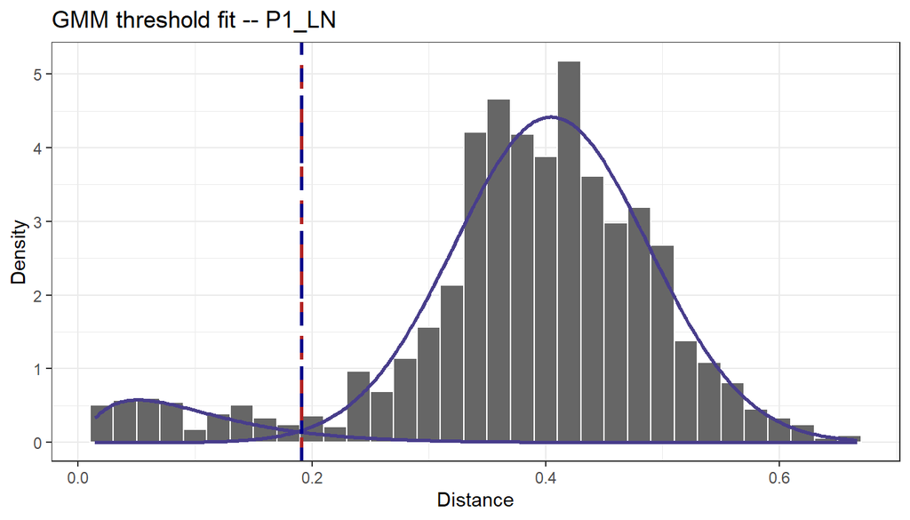

```
## Calculating nearest-neighbor distances for IGH sequences...
```

```
## Fitting GMM to determine automatic threshold...
```

```
## Automatic threshold: 0.08124
```

```
## Auto threshold for P1_PT: 0.08124
```

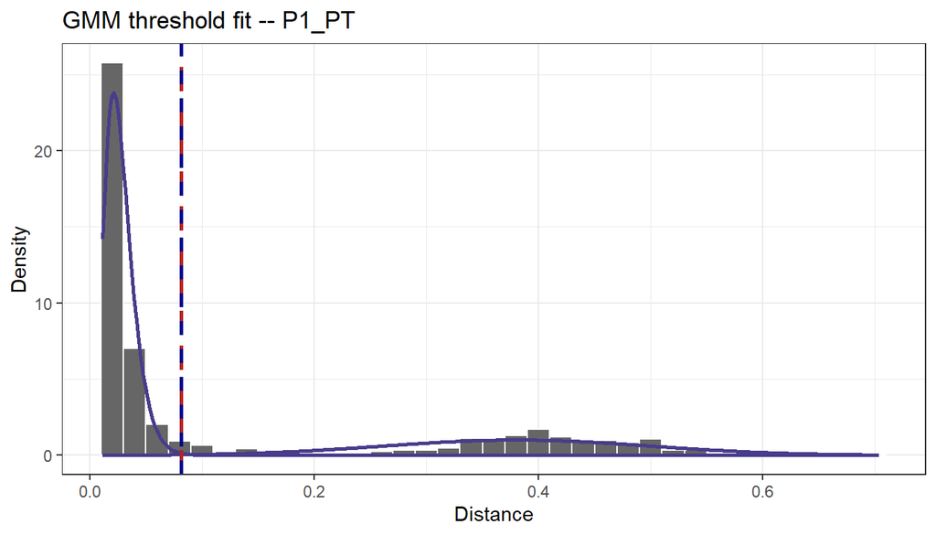

```r
# ---- User threshold override ------------------------------------------------
# By default the threshold is determined automatically by the GMM (NULL).
# If the automatic threshold looks wrong for a sample, set a numeric value here
# (e.g. 0.15) to override it. The override will appear as a red dashed line
# on the distance histogram so you can verify it visually.
#
# When to override: if the distribution is unimodal (no clear valley) and the
# auto threshold lands in an obviously wrong place, try a value in the
# 0.10-0.20 range and re-run this chunk.
USER_THRESHOLD <- list(
  P1_LN = NULL,   # NULL = use automatic threshold
  P1_PT = NULL    # NULL = use automatic threshold
)
# -----------------------------------------------------------------------------

threshold_list <- list()

# Set seed for reproducibility. SHazaM's GMM threshold fitting uses random
# initialization internally, so seeding here ensures the auto thresholds are
# bit-identical across runs.
set.seed(42)

for (s_id in names(bcr_list)) {

  thr_res   <- plot_clonal_thresholds(bcr_list[[s_id]],
                                      user_defined_threshold = USER_THRESHOLD[[s_id]])
  threshold <- if (!is.null(USER_THRESHOLD[[s_id]])) USER_THRESHOLD[[s_id]] else thr_res$auto_threshold
  message(if (!is.null(USER_THRESHOLD[[s_id]])) "User-defined" else "Auto",
          " threshold for ", s_id, ": ", signif(threshold, 4))

  print(thr_res$shazam_plot +
    ggplot2::ggtitle(paste("GMM threshold fit --", s_id)))

  threshold_list[[s_id]] <- threshold
}
```

## 1.3 Clone assignment

With the threshold in hand we run hierarchical clonal clustering. Two settings are worth noting:

- `only_heavy = TRUE`: clonal grouping is driven by the heavy chain. This is standard practice – the heavy chain CDR3 carries more sequence diversity and is more informative for clone definition.
- `split_light = TRUE`: after heavy-chain clustering, any clone containing cells with different light chains is split into sub-clones. This resolves cases where two cells share the same heavy chain rearrangement but carry different receptors.

After assigning clones we replace the default numeric clone IDs with informative strings. Each clone ID encodes four pieces of information: the sample ID, a unique random code, the clone size, and the heavy chain isotype composition. For example, `P1_LN_aB3x_14_G1M` is a clone from the LN sample with 14 cells carrying both IgG1 and IgM. The random code ensures uniqueness when data from multiple samples are later combined – no two clones from different samples can accidentally share an ID.

```r
# Set seed for reproducibility. annotate_clone_ids() generates a short random
# code as part of each clone ID (e.g. the "aB3x" in P1_LN_aB3x_14_G1M).
# Without a seed, those codes change on every run.
set.seed(42)

for (s_id in names(bcr_list)) {

  bcr <- bcr_list[[s_id]]
  bcr <- define_clones_basic(bcr, threshold = threshold_list[[s_id]], sample_id = s_id)
  bcr <- annotate_clone_ids(bcr, sample_id = s_id)
  qc_clone_assignment(bcr, bcr)

  bcr_list[[s_id]] <- bcr
}
```

```
## Running hierarchical clonal assignment for sample: P1_LN
```

```
## Running defineClonesScoper in single cell mode
```

```
## Clones assigned: 2176
```

```
## Cells excluded from clonal assignment: 0
```

```
## Annotating clone IDs for sample: P1_LN
```

```
## Clone ID annotation complete. Total clones: 2176
```

```
## Example clone IDs (format: SAMPLEID_CODE_SIZE_ISOTYPES):
```

```
## # A tibble: 5 × 3
##   clone_id           size isotype
##   <chr>             <int> <chr>
## 1 P1_LN_Yvk9_6_G2G4     6 IGHG2/IGHG4
## 2 P1_LN_QPMs_5_A1       5 IGHA1
## 3 P1_LN_XcB7_4_A1       4 IGHA1
## 4 P1_LN_0zZk_3_G1       3 IGHG1
## 5 P1_LN_APab_3_A1G1     3 IGHA1/IGHG1
```

```
## Running clone assignment QC...
```

```
##   Cells before clonal assignment: 2373
```

```
##   Cells assigned to clones:       2373
```

```
##   Cells lost:                     0
```

```
##   Total unique clones: 2176
```

```
## Running hierarchical clonal assignment for sample: P1_PT
```

```
## Running defineClonesScoper in single cell mode
```

```
## Clones assigned: 1622
```

```
## Cells excluded from clonal assignment: 0
```

```
## Annotating clone IDs for sample: P1_PT
```

```
## Clone ID annotation complete. Total clones: 1622
```

```
## Example clone IDs (format: SAMPLEID_CODE_SIZE_ISOTYPES):
```

```
## # A tibble: 5 × 3
##   clone_id                    size isotype
##   <chr>                      <int> <chr>
## 1 P1_PT_dyZf_138_G1G2          138 IGHG1/IGHG2
## 2 P1_PT_VA3i_127_A1A2G1G2G3M   127 IGHA1/IGHA2/IGHG1/IGHG2/IGHG3/IGHM
## 3 P1_PT_Skl5_107_G1G2G3        107 IGHG1/IGHG2/IGHG3
## 4 P1_PT_rf2S_92_G1G3M           92 IGHG1/IGHG3/IGHM
## 5 P1_PT_0L1W_81_G1G2            81 IGHG1/IGHG2
```

```
## Running clone assignment QC...
```

```
##   Cells before clonal assignment: 4307
```

```
##   Cells assigned to clones:       4307
```

```
##   Cells lost:                     0
```

```
##   Total unique clones: 1622
```

## 1.4 Germline reconstruction and somatic hypermutation

To measure somatic hypermutation (SHM) we need the unmutated germline sequence each B cell started from. We reconstruct this using the IMGT reference database via `dowser::createGermlines()`.

Once germlines are in hand, `shazam::observedMutations()` counts the differences between each sequence and its germline across the V gene region. We calculate both mutation frequency (proportion of positions mutated) and raw mutation count, stored as `mu_freq` and `mu_count` in the output. These will be used for SHM analysis in Part 3.

This is the slowest step in the pipeline – expect a minute or two per sample.

```r
for (s_id in names(bcr_list)) {
  message("Reconstructing germlines for: ", s_id)

  mut_outputs <- reconstruct_germlines_and_mutations(
    bcr_list[[s_id]],
    reference_dir = IMGT_REF_DIR,
    nproc         = 1
  )

  bcr_list[[s_id]] <- mut_outputs$results_with_mut
}
```

```
## Reconstructing germlines for: P1_LN
```

```
## Loading IMGT germline references from: C:/Users/natha/OneDrive/Documents/Immcantation/BCR_Tutorial/Github/human/vdj
```

```
## [1] "Read in 1197 from 17 fasta files"
```

```
## Reconstructing germline sequences...
```

```
## Calculating mutation frequencies...
```

```
## Calculating mutation counts...
```

```
## reconstruct_germlines_and_mutations complete.
```

```
## Reconstructing germlines for: P1_PT
```

```
## Loading IMGT germline references from: C:/Users/natha/OneDrive/Documents/Immcantation/BCR_Tutorial/Github/human/vdj
```

```
## [1] "Read in 1197 from 17 fasta files"
```

```
## Reconstructing germline sequences...
```

```
## Calculating mutation frequencies...
```

```
## Calculating mutation counts...
```

```
## reconstruct_germlines_and_mutations complete.
```

## 1.5 Save

We save a TSV for each sample. These files are the input for Step 4 in Part 2 (Add BCR to Seurat), after GEX QC and doublet removal are complete. They are also used directly in Part 3 for repertoire visualization.

```r
for (s in samples) {
  bcr_tsv <- file.path(s$output_dir, paste0(s$sample_id, "_bcr_data.tsv"))
  write.table(bcr_list[[s$sample_id]], file = bcr_tsv,
              sep = "\t", row.names = FALSE, quote = FALSE)
  message("Saved: ", bcr_tsv)
}
```

```
## Saved: C:/Users/natha/OneDrive/Documents/Immcantation/BCR_Tutorial/Github/P1_LN/Output/P1_LN_bcr_data.tsv
```

```
## Saved: C:/Users/natha/OneDrive/Documents/Immcantation/BCR_Tutorial/Github/P1_PT/Output/P1_PT_bcr_data.tsv
```

## 1.6 Repertoire overview

Before moving to GEX it is worth getting a quick overview of each sample’s repertoire. Three plots are shown for each sample:

- **Rank-abundance**: each point is a clone ranked by size. A flat curve means many clones of similar size (polyclonal). A steep early drop-off means a few dominant clones (oligoclonal).
- **Clone size distribution**: how many clones have 1 cell, 2 cells, 3 cells, and so on.
- **Mutation frequency by isotype**: SHM frequency split by heavy chain isotype. IgM should be near zero (naive/unswitched); IgG and IgA should be higher, reflecting affinity maturation through class switching.

```
## Calculating rank-abundance curves...
```

```
## Calculating clone size distribution...
```

```
## Calculating clonal diversity...
```

```
## visualize_clones complete.
```

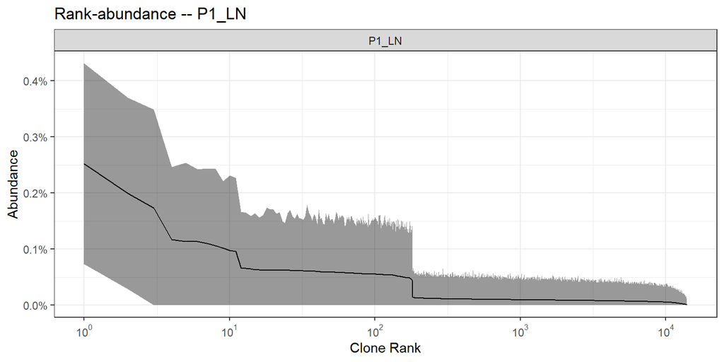

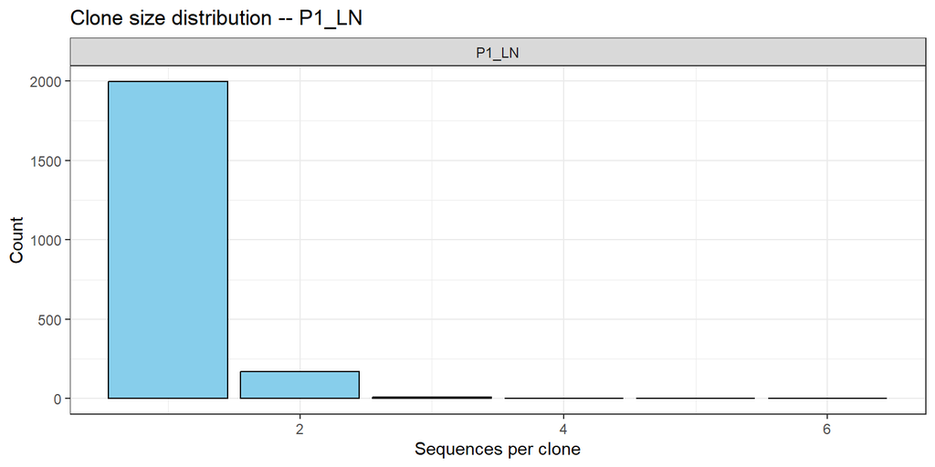

```
## plot_mutation_frequencies complete.
```

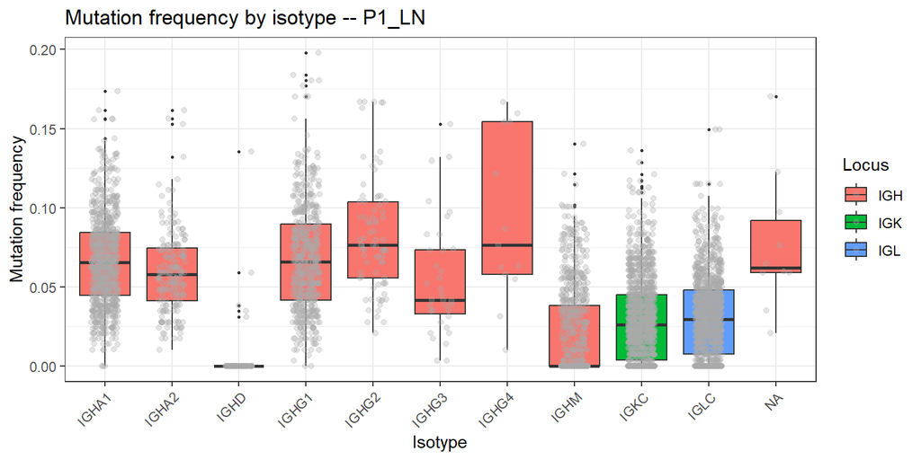

```
## Calculating rank-abundance curves...
```

```
## Calculating clone size distribution...
```

```
## Calculating clonal diversity...
```

```
## visualize_clones complete.
```

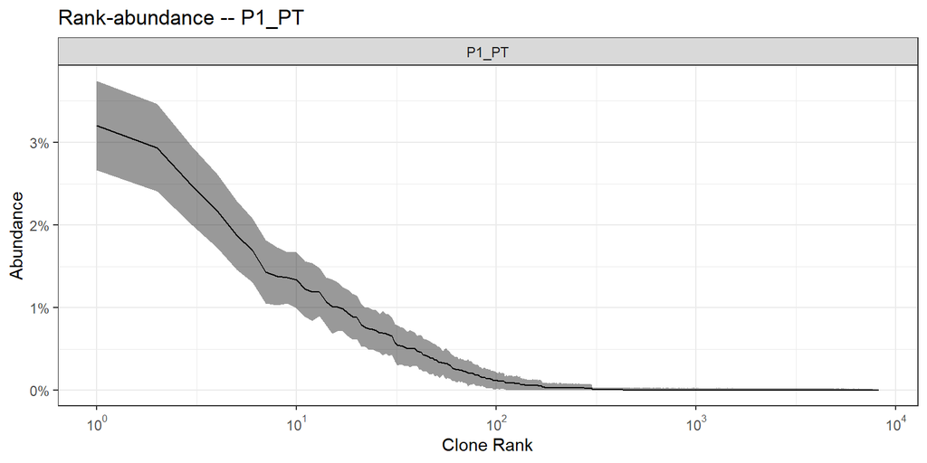

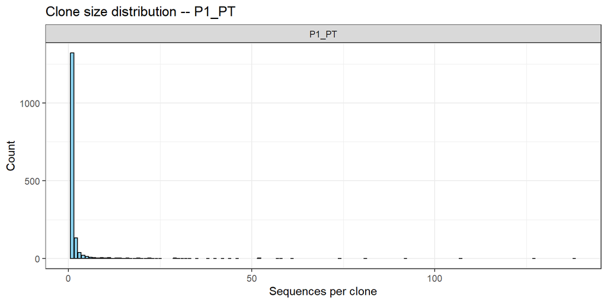

```
## plot_mutation_frequencies complete.
```

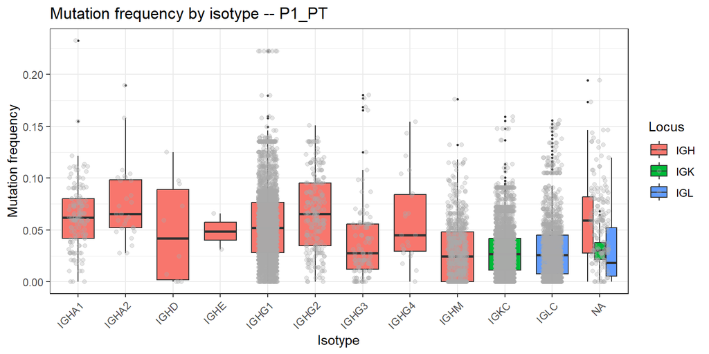

```r
for (s_id in names(bcr_list)) {

  bcr <- bcr_list[[s_id]]

  clone_plots <- visualize_clones(bcr)
  print(clone_plots$rank_abundance_plot +
    ggplot2::ggtitle(paste("Rank-abundance --", s_id)))
  print(clone_plots$clone_size_plot +
    ggplot2::ggtitle(paste("Clone size distribution --", s_id)))

  mf_plots <- plot_mutation_frequencies(bcr)
  print(mf_plots$by_isotype +
    ggplot2::ggtitle(paste("Mutation frequency by isotype --", s_id)))
}
```

### What the plots show

The two samples show a striking contrast that reflects their biology:

**P1_LN (lymph node)** is a polyclonal, actively diversifying repertoire. The rank-abundance curve is flat, the clone size distribution is dominated by singletons, and the mutation frequency plot shows the expected isotype hierarchy – IgM near zero, IgG and IgA progressively higher. This is consistent with an active germinal center producing a broad, maturing B cell response.

*Part 1 complete. TSV files saved to the Output folder for each sample. Continue to Part 2 (BCR_GEX_Tutorial_Part2.Rmd) for GEX QC, integration, and cluster annotation.*